# Tuvalu Trust Index

Institutional

This Community Trust Index evaluates institutional trust in the Tuvalu Red Cross Society (TRCS) through competencies and values, assessing perceptions across several subdimensions that drive overall trust perception. By identifying strengths and areas for improvement, it aims to enhance community engagement and inform policy decisions. Ultimately, the insights gained will foster a more cohesive and trusting environment, contributing to Tuvalu’s sustainable development and collective well-being.

# Sampling

The survey was conducted by the Tuvalu Red Cross Society (TRCS) during the summer of 2023. TRCS volunteers administered the survey, which focused on questions related to trust as part of the Building Trust project. The survey reached 150 respondents across the Funafuti islands.

A representative sample of households were randomly selected based on the Funafuti Island map and zoning, using a single-stage cluster sampling approach.

*See metrics: Metrics*

## Geographic

Two neighborhood grids were selected within the target communities (Alapi, Fakaifou, Kavatoetoe, Lofeagai, Senala, Teone, and Vaiaku of the Funafuti island).

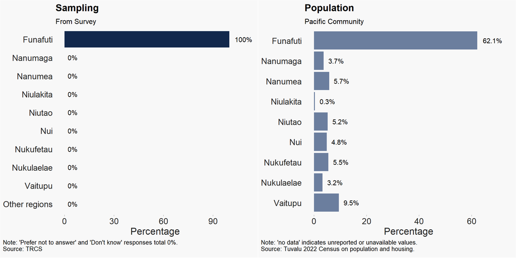

## Coverage

[interactive chart not shown]

## Gender and Age

Compared to the overall Tuvalu population, in the sample women especially over 60 and under 40 are over-represented.

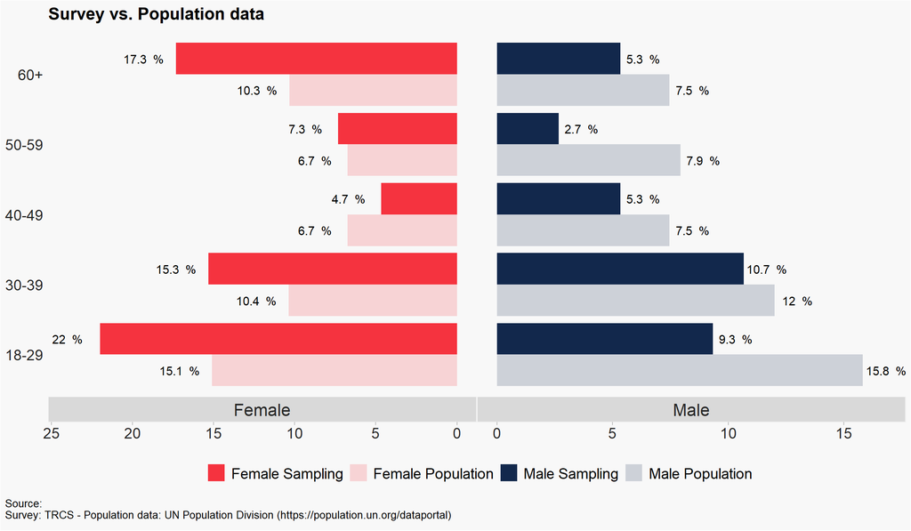

## Education

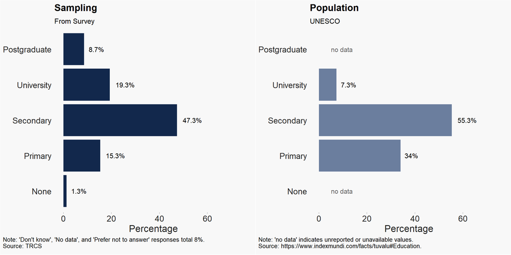

## Employment

The sampling distribution reveals a high proportion of Homeworkers (30%) and individuals not currently in paid work (22.7%), with under representation in sectors like farming/fishing (1.3%) and health/education (0.7%-1.3%) compared to Tuvalu’s general employment trends, where fishing, agriculture, and public services are dominant. This discrepancy suggests the survey may not fully capture key economic sectors. Business owners (8.7%) align with Tuvalu’s entrepreneurial growth, but the low representation of traditional livelihoods indicates a need for more targeted sampling. Overall, the sample provides insights but may not be fully representative of Tuvalu’s employment landscape. (Sources: World Bank, Tuvalu Department of Statistics, and regional employment reports).

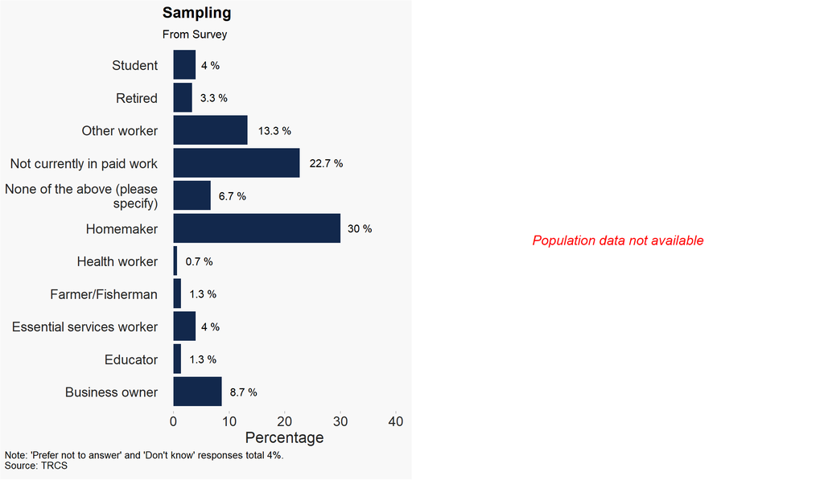

# Survey Results

The charts below present the survey answers as percentages, offering visualization of the Community Trust levels by subdimensions. They illustrate the distribution of community’s perceptions of the competencies and values.

## Perception of trust

### Competencies

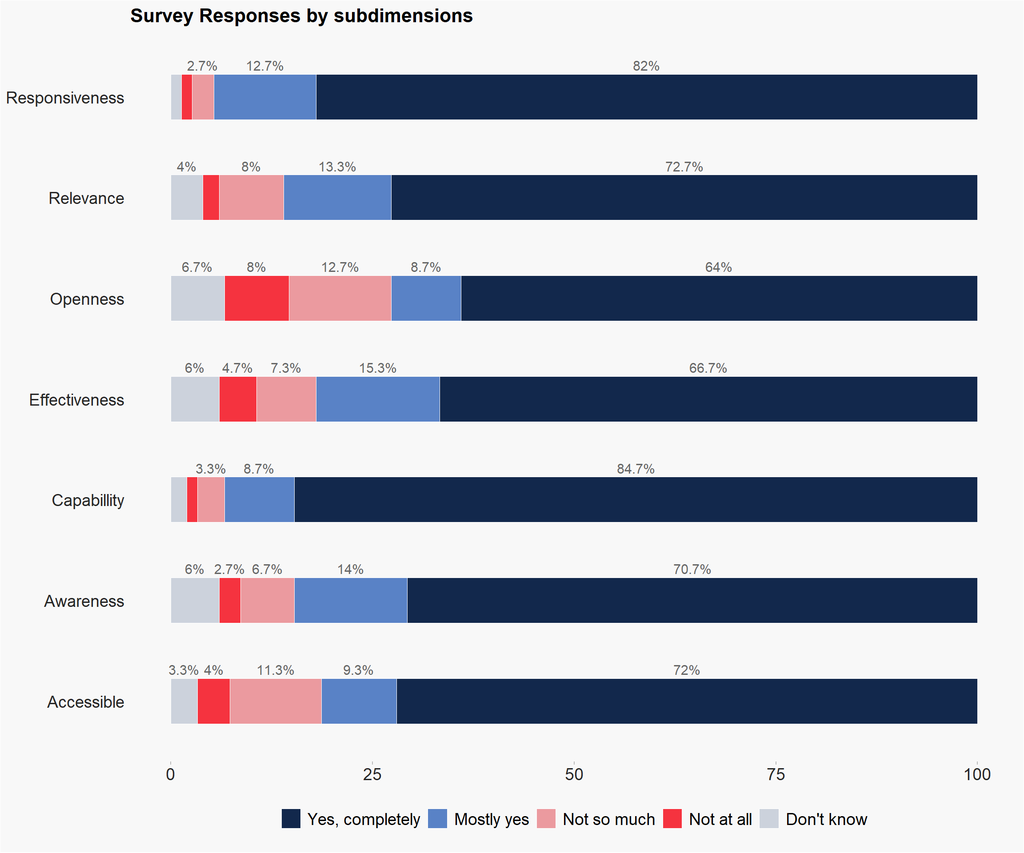

### Values

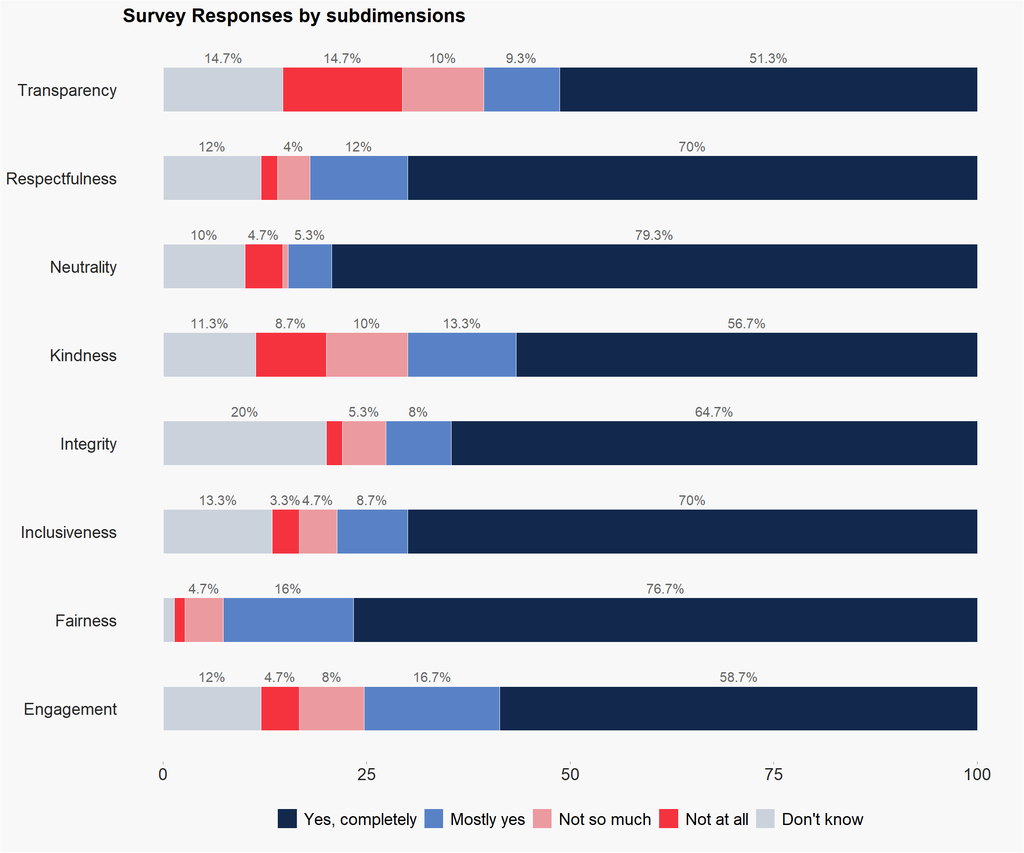

## Contextual questions

This section presents findings on community members’ experiences with and behaviors toward the Red Cross. These questions explore interactions, perceptions, and engagement patterns, offering insights into how the Red Cross is viewed and utilized within the community.

### Experiences

Survey data shows that more than 2/3 of the respondents have requested and received support from the TRCS and have provided donations. More than half of the respondents indicated to have volunteered for the TRCS.

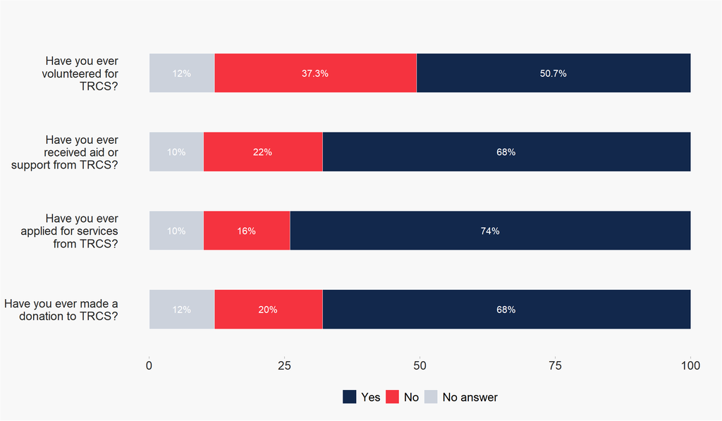

### Behaviours

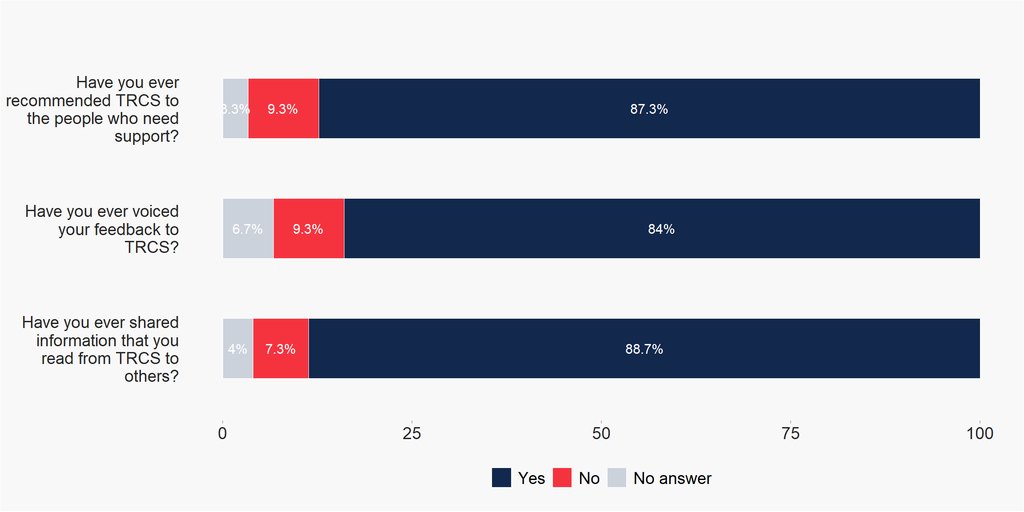

# Score

This score is derived from responses to questions that assess perceptions of competencies and values, providing a comprehensive measure of trust. A higher score indicates stronger trust, suggesting that community members believe their needs are being addressed and their values are respected. *Learn more about scoring method: Methods*

## Overall Score

The weighted results for the trust question on competencies show very little variation, only the question on openness of the Tuvalu Red Cross Society had a lower mean value than all the other question on competencies. We see slightly more variation in terms of the questions on values where items on transparency and kindness show a lower mean (2.3 out of the 0-3 scale). However, overall the responses are very positive (with an average of 2.6 for both values and competencies).

*Learn more about weighting process: Weighting*

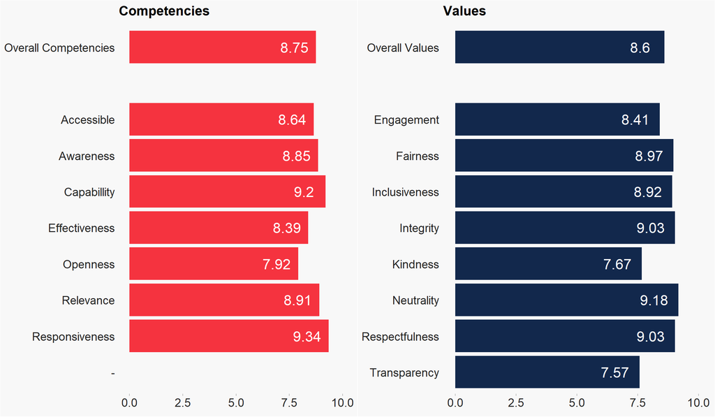

## Score by factors

*Distribution of mean scores for values and competencies per demographic questions*

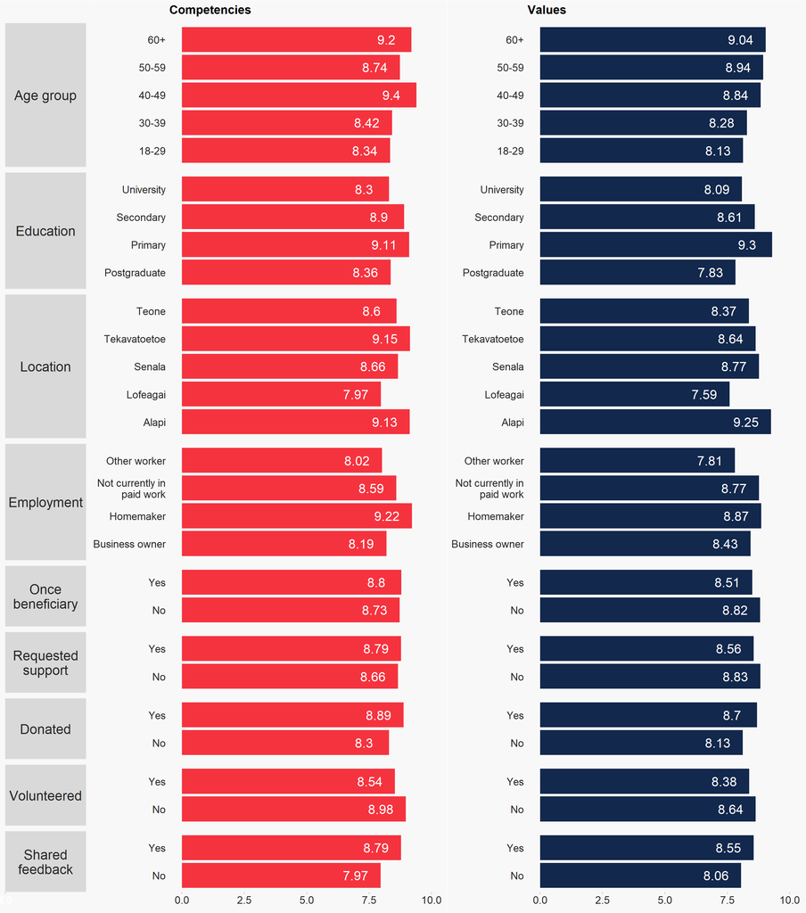

## Score by respondent profile

When looking at the sub-groups of people who volunteered and beneficiaries as well as others, we see that small difference between the groups, which are not significant since the group sizes are small.

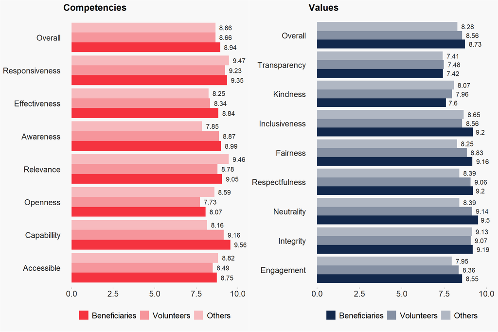

# Methods and Metrics

## Metrics

### Gender

Respondents by Gender

| Gender | Total Respondents | Percentage (%) |
| --- | --- | --- |
| Female | 100 | 66.7 |
| Male | 50 | 33.3 |
| Other or did not answer | 0 | 0.0 |
| Total | 150 | 100.0 |

### Age

Respondents by Age Group

| Age Group | Total Respondents | Percentage (%) |
| --- | --- | --- |
| 18-29 | 47 | 31.3 |
| 30-39 | 39 | 26.0 |
| 40-49 | 15 | 10.0 |
| 50-59 | 15 | 10.0 |
| 60+ | 34 | 22.7 |

### Geographic

Respondents by Municipality and Region

| Region | Municipality | Total Respondents | Percentage (%) |
| --- | --- | --- | --- |
| Funafuti | TOTAL | 150 | 100.0 |
| Funafuti | Alapi | 34 | 22.7 |
| Funafuti | Lofeagai | 33 | 22.0 |
| Funafuti | Teone | 29 | 19.3 |
| Funafuti | Tekavatoetoe | 27 | 18.0 |
| Funafuti | Senala | 12 | 8.0 |
| Funafuti | Fakaifou | 9 | 6.0 |
| Funafuti | Vaiaku | 6 | 4.0 |

### Relationship with RC

Respondents by relationship with RC

| Profile | Total Respondents |
| --- | --- |
| Aid recipient | 102 |
| Volunteer | 76 |
| Other | 22 |

## Methods

**Scoring methodology**

To determine the score, we employ the following method:

1. Survey Structure The CTI survey includes multiple questions grouped under sub-dimensions of two main categories:
   - Competencies (e.g., reliability, effectiveness, technical proficiency)
   - Values (e.g., ethics, integrity, fairness, transparency)
2. Sub-Dimension Scoring

   Each sub-dimension comprises several survey items (questions).Respondents answer on a Likert-type scale (1 to 4 - Don’t not is excluded). For each sub-dimension:

   *Sub-dimension Score = ∑ (Weighted Response Scores) / Number of Items*

If weights are not empirically derived, equal weighting is typically applied to each item.

3. Dimension Scoring

Once all sub-dimension scores are calculated, the Competency Score and Values Score are each derived as the arithmetic mean of their respective sub-dimension scores:

- *Competency Score = ∑(Sub-dimension Scores for Competency) /𝑛*
- *Values Score = ∑(Sub-dimension Scores for Values)/𝑚*

where 𝑛 and 𝑚 are the number of sub-dimensions in each category.

4. Overall Scoring

   The final Community Trust Index score is the arithmetic mean of the Competency and Values scores:
- *CTI Score = (Competency Score + Values Score)/2*

## Weighting

**Weighting vs. unweighting**

The survey data has been weighted based on Tuvalu census 2017 of the Funafuti population. In addition, adjustments were made to re-balance the gender ratio in accordance with census data (i.e., 47.6% females vs. 52.4% males in Funafuti). For comparison we included also un-weighted results in the graph, as well as the sub-set of the data for volunteers, people who indicate to have received support from the TRCS as well as the group that neither volunteered nor received assistance.

Overall, we see no major differences between these groups.

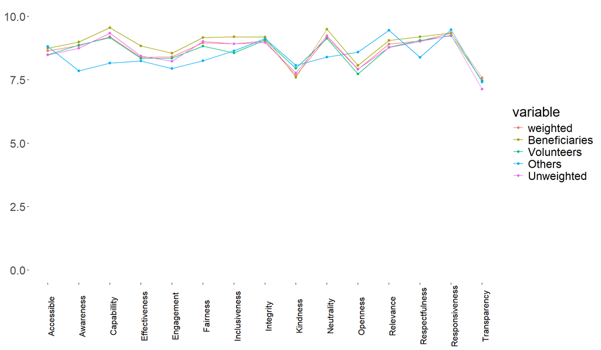

## Drivers Correlation

**Correlation matrix**

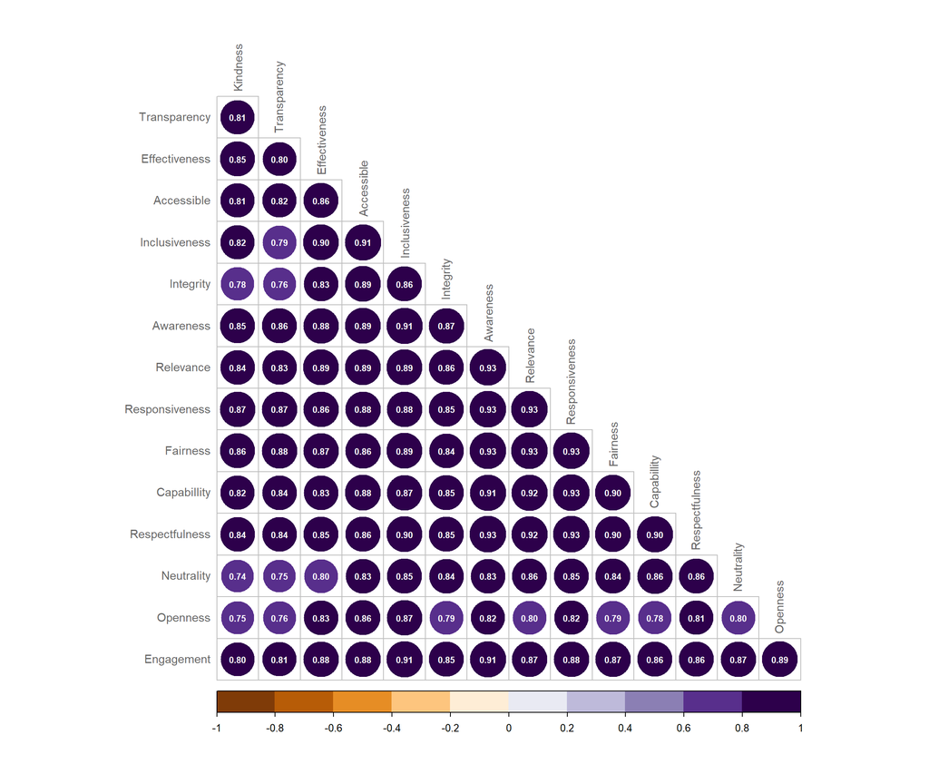

## Significance testing

**Significance testing**

When checking for significant differences between the groups we use a t-test to compare means of the competency and value questions, for all the questions, the results are indeed not significant due to the small sample size. The table shows whether a results for beneficiaries, volunteers and others are significantly different form each other. We used a 95% confidence level and corrected the p-values using a multiple comparisons correction.

| Dimension | Drivers | Volunteer-Other | Volunteer-Beneficiary | Benficiary-Other |
| --- | --- | --- | --- | --- |
| Competency | Capabillity | No | No | No |
| Competency | Responsiveness | No | No | No |
| Competency | Awareness | No | No | No |
| Competency | Accessible | No | No | No |
| Competency | Openness | No | No | No |
| Competency | Relevance | No | No | No |
| Competency | Effectiveness | No | No | No |
| Value | Kindness | No | No | No |
| Value | Fairness | No | No | No |
| Value | Respectfulness | No | No | No |
| Value | Engagement | No | No | No |
| Value | Integrity | No | No | No |
| Value | Transparency | No | No | No |
| Value | Neutrality | No | No | No |
| Value | Inclusiveness | No | No | No |

# Download

Download Summary Excel File